# Manuscript figures

Nicolas Delhomme and Fai Theerarat Kochakarn

2024-01-02

# 1 Setup

- Libraries

```r
suppressPackageStartupMessages({
  library(here)
  library(KEGGREST)
  library(magrittr)
  library(pathview)
  library(S4Vectors)
  library(stringr)
  library(tidyverse)
    library(cowplot)
})
```

- Helper functions

```r
source(here("UPSCb-common/src/R/featureSelection.R"))
```

- Palette

```r
hpal <- colorRampPalette(c("blue","white","red"))(100)
```

- DE genes

```r
degList <- lapply(sort(list.files(here("data/analysis/DE/Response"),pattern="*_genes.csv",full.names=TRUE)),
                  read_csv,show_col_types = FALSE,skip=1,
                  col_names=c("ID","baseMean","log2FoldChange","lfcSE","stat","pvalue","padj"))

names(degList) <- c("acute","early","late")

degListPerTimePoint <- lapply(sort(list.files(here("data/analysis/DE"),pattern="*vs_std_genes.csv",full.names=TRUE)),
                                    read_csv,show_col_types = FALSE,skip=1,
                                    col_names=c("ID","baseMean","log2FoldChange","lfcSE","stat","pvalue","padj"))

names(degListPerTimePoint) <- c("120hrs_vs_ctrl","12hrs_vs_ctrl","24hrs_vs_ctrl","4hrs_vs_ctrl","1hr_vs_ctrl","72hrs_vs_ctrl")
```

- Annotation

```r
annot <- read_tsv(here("data/analysis/cold-response/algae_GO_annotation.tsv"),
                  show_col_types=FALSE)
```

- Expression

```r
load(here("data/analysis/salmon/dds-sample-swap-corrected.rda"))
load(here("data/analysis/DE/vst-aware.rda"))
dds$Response <- factor(levels=c("control","acute","early","late"),
                       sub(".*hrs","late",
                           gsub("12hrs|^4hrs","early",
                                sub("60min","acute",
                                    sub("std","control",dds$Time)))))

dds$RenameTime <- factor(levels=c("control","1hr","4hrs","12hrs","24hrs","72hrs","120hrs"),
                         sub("60min","1hr",
                             sub("std","control",dds$Time)))

scaledAvgExp <- t(scale(t(sapply(split.data.frame(t(vst),dds$Response),colMeans))))
scaledAvgExp[is.nan(scaledAvgExp)] <- 0
scaledAvgExp %<>% as.data.frame() %>% rownames_to_column("TxID") %>% as_tibble()
```

# 2 Figures

## 2.1 Figure 2

```r
conds <- dds$RenameTime
sels <- rangeFeatureSelect(counts=vst,
                                                     conditions=conds,
                                                     nrep=3,
                                                     plot=FALSE)
vst.cutoff <- 1
mat <- t(scale(t(vst[sels[[vst.cutoff+1]],])))
colnames(mat) <- sub("60min","1hr",sub("std","control",paste0(dds$Time,"_",dds$Replicate)))
```

Rearrange the column

```r
mat <- mat[,c("control_A","control_D","control_B","control_C",
                            "1hr_D","1hr_A","1hr_B","1hr_C",
                            "4hrs_D","4hrs_B","4hrs_A","4hrs_C",
                            "12hrs_D","12hrs_B","12hrs_A","12hrs_C",
                            "24hrs_D","24hrs_B","24hrs_A","24hrs_C",
                            "72hrs_D","72hrs_C","72hrs_B","72hrs_A",
                            "120hrs_C","120hrs_D","120hrs_A","120hrs_B")]
```

annotation column

```r
col_anno <- str_sub(colnames(mat),end = -3) %>% as.data.frame()
colnames(col_anno) <- "Time"
col_anno$Time <- factor(col_anno$Time, levels=c("control","1hr","4hrs","12hrs","24hrs","72hrs","120hrs"))
rownames(col_anno) <- colnames(mat)
```

annotation colors

```r
col_anno_col = brewer.pal(nlevels(conds),"Dark2")
names(col_anno_col) <- c("control","1hr","4hrs","12hrs","24hrs","72hrs","120hrs")
col_anno_col=list(Time = col_anno_col)
```

### 2.1.1 Heatmap

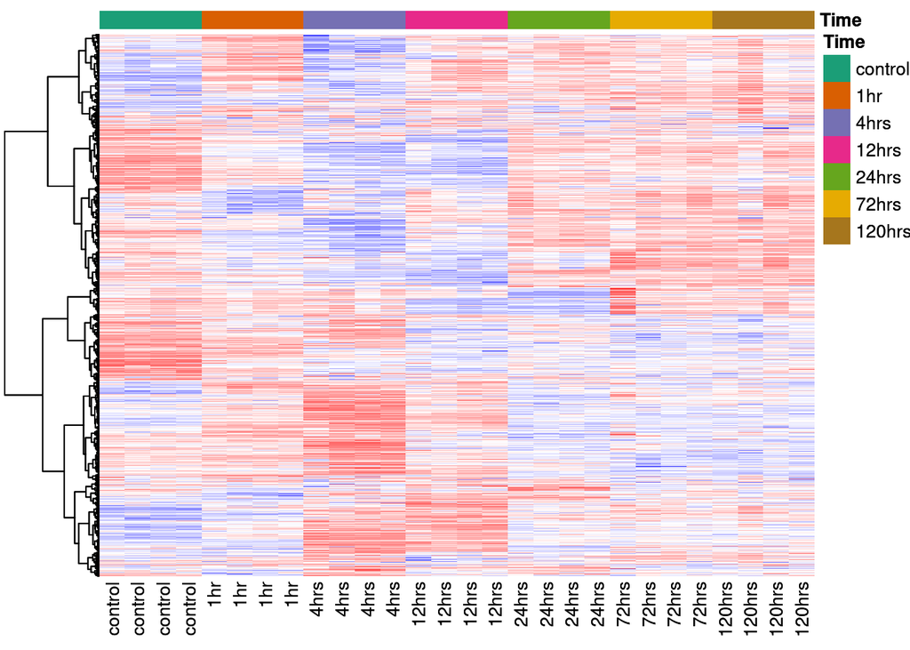

```r
hm2 <- pheatmap(mat,
                                color = hpal,
                                border_color = NA,
                                cluster_cols = FALSE,
                                clustering_distance_rows = "correlation",
                                clustering_method = "ward.D2",
                                annotation_col = col_anno,
                                show_rownames = FALSE,
                                labels_col = col_anno$Time,
                                angle_col = 90,
                                annotation_colors = col_anno_col,
                                legend = FALSE)

hm2
```

## 2.2 Figure 3

### 2.2.1 Lipids

```r
lipidTerms <- tibble(Term=scan(here("doc/Algae-selected-lipid-GO-terms.tsv"),what="character",sep="\n"))
```

Data manipulation

1. we find the genes that are annotated with the terms

```r
lipidTerms$Tx <- lapply(lipidTerms$Term,function(trm,ant){ant$TxID[grep(trm,ant$Term)]},annot)
```

2. we count them and remove terms that are not found (most likely Aman used the whole transcriptome and not the algae subset to look up the terms)

```r
lipidTerms %<>% mutate(Ntx=elementNROWS(lipidTerms$Tx)) %>% filter(Ntx>0)
```

3. we find how many are in the DEG lists

```r
lipidTerms %<>% bind_cols(sapply(sapply(degList,"[[","ID"),function(d,p){sapply(lapply(p,"%in%",d),sum)},lipidTerms$Tx))
```

4. We removed the absent ones

```r
lipidTerms %<>% filter(rowSums(lipidTerms[,names(degList)])>0)
```

5. We calculate a frequency

```r
freq <- lipidTerms[,names(degList)] / lipidTerms$Ntx

names(freq) <- paste0("percent_",names(freq))

lipidTerms %<>% bind_cols(freq)
```

6. We plot the frequency (0 to 0.5 to 1 - blue to white to red) as a heatmap, removed the dendrograms and clustering. Add the numbers as cell labels.

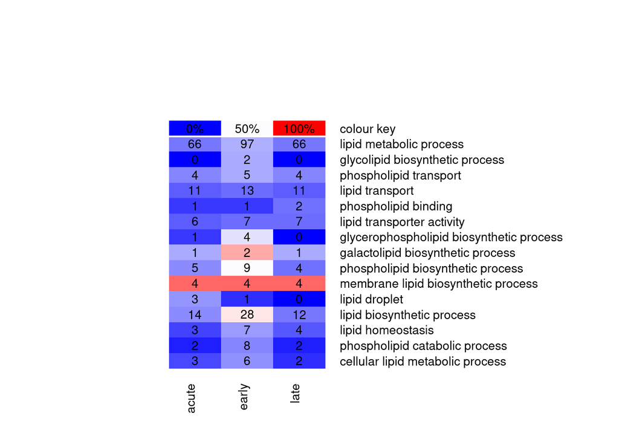

```r
gplots::heatmap.2(rbind(c(percent_acute=0,percent_early=0.5,percent_late=1),
                        as.matrix(lipidTerms[,c("percent_acute","percent_early","percent_late")])),
                  trace = "none",dendrogram="none",
                  Colv=FALSE,Rowv=FALSE,key=FALSE,
                  labCol = names(degList),margins=c(5,20),
                  labRow = c("colour key",lipidTerms$Term),
                  breaks = seq(0,1,0.01),
                  cexCol = 1,cexRow=1,notecol="black",
                  cellnote=rbind(c("0%","50%","100%"),
                                 as.matrix(lipidTerms[,c("acute","early","late")])),
                  col=hpal,rowsep=1,sepcolor="white")
```

```r
# write_tsv(lipidTerms %>% mutate(Tx=sapply(lipidTerms$Tx,paste,collapse="|")),
#           here("data/analysis/lipid/lipid_go_term_summary.tsv"))
```

### 2.2.2 Carbohydrates

```r
carbohydrateTerms <- tibble(Term=scan(here("doc/Algae-selected-carbohydrate-GO-terms.tsv"),what="character",sep="\n"))
```

Data manipulation

1. we find the genes that are annotated with the terms

```r
carbohydrateTerms$Tx <- lapply(carbohydrateTerms$Term,function(trm,ant){ant$TxID[grep(trm,ant$Term)]},annot)
```

2. we count them and remove terms that are not found (most likely Aman used the whole transcriptome and not the algae subset to look up the terms)

```r
carbohydrateTerms %<>% mutate(Ntx=elementNROWS(carbohydrateTerms$Tx)) %>% filter(Ntx>0)
```

3. we find how many are in the DEG lists

```r
carbohydrateTerms %<>% bind_cols(sapply(sapply(degList,"[[","ID"),function(d,p){sapply(lapply(p,"%in%",d),sum)},carbohydrateTerms$Tx))
```

4. We removed the absent ones

```r
carbohydrateTerms %<>% filter(rowSums(carbohydrateTerms[,names(degList)])>0)
```

5. We calculate a frequency

```r
freq <- carbohydrateTerms[,names(degList)] / carbohydrateTerms$Ntx

names(freq) <- paste0("percent_",names(freq))

carbohydrateTerms %<>% bind_cols(freq)
```

6. We plot the frequency (0 to 0.5 to 1 - blue to white to red) as a heatmap, removed the dendrograms and clustering. Add the numbers as cell labels.

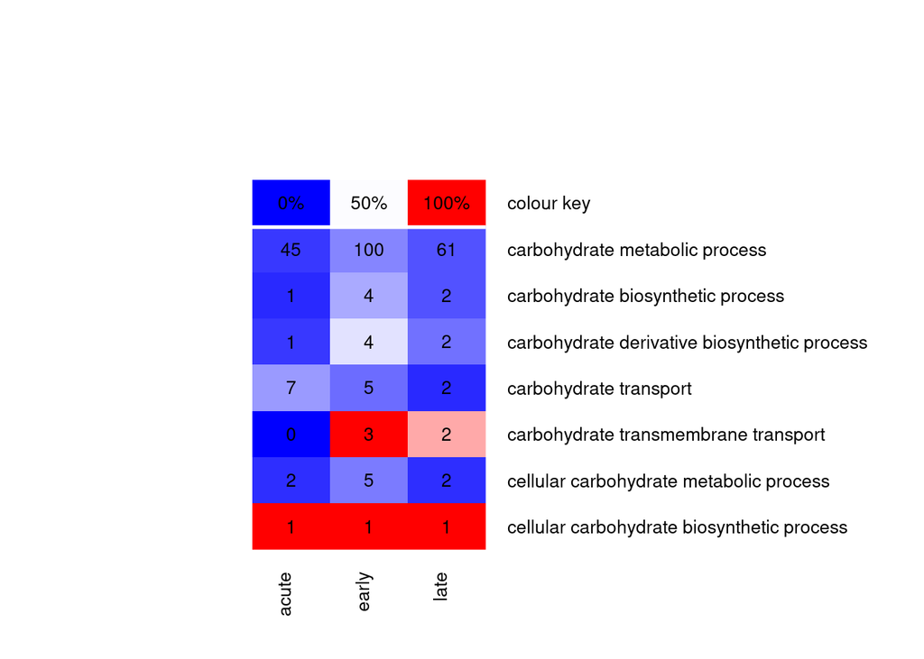

```r
gplots::heatmap.2(rbind(c(percent_acute=0,percent_early=0.5,percent_late=1),
                        as.matrix(carbohydrateTerms[,c("percent_acute","percent_early","percent_late")])),
                  trace = "none",dendrogram="none",
                  Colv=FALSE,Rowv=FALSE,key=FALSE,
                  labCol = names(degList),margins=c(5,20),
                  labRow = c("colour key",carbohydrateTerms$Term),
                  breaks = seq(0,1,0.01),
                  cexCol = 1,cexRow=1,notecol="black",
                  cellnote=rbind(c("0%","50%","100%"),
                                 as.matrix(carbohydrateTerms[,c("acute","early","late")])),
                  col=hpal,rowsep=1,sepcolor="white")
```

```r
# write_tsv(carbohydrateTerms %>% mutate(Tx=sapply(carbohydrateTerms$Tx,paste,collapse="|")),
#           here("data/analysis/carbs/carbohydrates_go_term_summary.tsv"))
```

## 2.3 Figure 4

### 2.3.1 Build the annotation

First we read the annotation and retrieve the transcript ID and enzyme code

```r
# eCannot <- read_tsv(here("data/analysis/cold-response/algae_annotation.tsv"),
#                   show_col_types=FALSE) %>%
#   select(`Sequence Name`,`Enzyme Code`) %>%
#   dplyr::rename(TxID=`Sequence Name`,EC=`Enzyme Code`) %>%
#   filter(!is.na(EC))
```

We convert to a longer format

```r
# eCannot %<>% separate_longer_delim(EC,"|")
```

We use the REST API to fetch the corresponding pathways

```r
# uEC <- eCannot %>% select(EC) %>% mutate(EC=sub("EC","enzyme",EC)) %>% distinct() %>% unlist(use.names=FALSE)
```

We remove entries that have only a 3rd level, no 4th level EC code

```r
# uEC <- uEC[elementNROWS(sapply(uEC,gregexpr,pattern="\\."))==3]
```

We can only get 10 entries at a time, so we iterate. It is very slow, several hours.

```r
# pthws <- do.call("c",
#                     lapply(breakInChunks(totalsize = length(uEC),chunksize = 10),
#                            function(rng,ecs){
#                              message(sprintf("Running range starting at %s",rng[1]))
#                              lst <- lapply(keggGet(ecs[rng]),"[[","PATHWAY")
#                              names(lst) <- ecs[rng]
#                              return(lst)
#                            },uEC))
# stopifnot(all(names(pthws) == uEC))
```

Report as a dictionary of pathways

```r
# upthw <- unlist(pthws)
# names(upthw) <- sub(".*\\.","",names(upthw))
# upthw <- upthw[!duplicated(upthw)]
# pthw <- tibble(ID=names(upthw),
#                Description=upthw)
```

Export the dictionary

```r
# write_tsv(pthw,here("data/analysis/annotation/kegg-pathways-dictionary.tsv"))
pthw <- read_tsv(here("data/analysis/annotation/kegg-pathways-dictionary.tsv"))
```

Combine the dictionary with the transcript and remove NA PID rows (EC code that have been made obsolete)

```r
# eCannot %<>% left_join(tibble(EC=sub("enzyme","EC",rep(names(pthws),elementNROWS(pthws))),
#        PID=unlist(sapply(pthws,names),use.names=FALSE),
#        PDESC=unlist(pthws,use.names=FALSE)
#        ),by="EC",relationship = "many-to-many") %>% filter(!is.na(PID))
```

Export the kegg annotation

```r
# write_tsv(eCannot,here("data/analysis/annotation/kegg-transcript-pathway-mapping.tsv"))
eCannot <- read_tsv(here("data/analysis/annotation/kegg-transcript-pathway-mapping.tsv"))
```

Export the transcript annotation

```r
# kAnnot <- t(sapply(split.data.frame(as.data.frame(eCannot)[,-1],eCannot$TxID),
#        function(df){apply(df,2,paste,collapse="|")})) %>%
#   as.data.frame() %>% rownames_to_column("TxID") %>% as_tibble()

# write_tsv(kAnnot,here("data/analysis/annotation/algae_KEGG_annotation.tsv"))
kAnnot <- read_tsv(here("data/analysis/annotation/algae_KEGG_annotation.tsv"))
```

### 2.3.2 Mock figure for fatty acids

1. we find the terms

```r
fAcids <- eCannot[grepl("fatty",eCannot$PDESC,ignore.case=TRUE),]
```

2. we get the transcript lists and their length

```r
fAcids %<>% group_by(PDESC) %>% summarise(TX=list(TxID)) %>% mutate(Ntx=elementNROWS(TX))
```

3. we find how many are in the DEG lists

```r
fAcids %<>% bind_cols(sapply(sapply(degList,"[[","ID"),function(d,p){sapply(lapply(p,"%in%",d),sum)},fAcids$TX))
```

4. We calculate a frequency

```r
freq <- fAcids[,names(degList)] / fAcids$Ntx

names(freq) <- paste0("percent_",names(freq))

fAcids %<>% bind_cols(freq)
```

5. We plot the frequency (0 to 0.5 to 1 - blue to white to red) as a heatmap, removed the dendrograms and clustering. Add the numbers as cell labels.

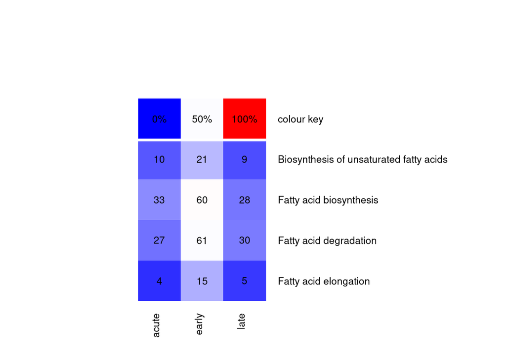

```r
gplots::heatmap.2(rbind(c(percent_acute=0,percent_early=0.5,percent_late=1),
  as.matrix(fAcids[,c("percent_acute","percent_early","percent_late")])),
                  trace = "none",dendrogram="none",
                  Colv=FALSE,Rowv=FALSE,key=FALSE,
                  labCol = names(degList),margins=c(5,20),
                  labRow = c("colour key",fAcids$PDESC),
                  breaks = seq(0,1,0.01),
                  cexCol = 1,cexRow=1,notecol="black",
                  cellnote=rbind(c("0%","50%","100%"),
                                 as.matrix(fAcids[,c("acute","early","late")])),
                  col=hpal,rowsep=1,sepcolor="white")
```

6. Write the results

```r
# dir.create(here("data/analysis/kegg"),showWarnings=FALSE)
# write_tsv(fAcids %>% mutate(TX=sapply(fAcids$TX,paste,collapse="|")),
#           here("data/analysis/kegg/fatty_acids_pathways_summary.tsv"))
```

## 2.4 Figure 5

1. Getting GO related to cold

```r
toicold <- annot[grepl("cold",annot$Term),c("GOID","Term")]
toicold %<>% separate_longer_delim(everything(),delim="|") %>% distinct() %>% filter(grepl("cold",Term))

message(sprintf("There are %s GO terms related to cold in the assembly",nrow(toicold)))
```

```
## There are 3 GO terms related to cold in the assembly
```

```r
knitr::kable(toicold)
```

| GOID | Term |
| --- | --- |
| GO:0009409 | response to cold |
| GO:0009631 | cold acclimation |
| GO:0070417 | cellular response to cold |

2. Getting genes with GO related to cold

```r
goicold <- unlist(as.vector(annot[Reduce("|",lapply(toicold$GOID,grepl,annot$GOID)),"TxID"]))
message(sprintf("There are %s candidates in the assembly",length(goicold)))
```

```
## There are 85 candidates in the assembly
```

3. Counting cold-related genes in DEG

```r
countcold <- as.data.frame(matrix(data = 0, nrow = length(degList), ncol = 2, dimnames = list(names(degList),c("Up","Down"))))
countcold$Up <- as.numeric(lapply(names(degList), function(x) sum((degList[[x]][["ID"]] %in% goicold)*(degList[[x]][["log2FoldChange"]] > 0))))
countcold$Down <- as.numeric(lapply(names(degList), function(x) sum((degList[[x]][["ID"]] %in% goicold)*(degList[[x]][["log2FoldChange"]] < 0))))
countcold$NonSig <- length(goicold) - countcold$Up - countcold$Down
countcold$time <- rownames(countcold)

countcoldtimepoint <- as.data.frame(matrix(data = 0, nrow = length(degListPerTimePoint), ncol = 2, dimnames = list(names(degListPerTimePoint),c("Up","Down"))))
countcoldtimepoint$Up <- as.numeric(lapply(names(degListPerTimePoint), function(x) sum((degListPerTimePoint[[x]][["ID"]] %in% goicold)*(degListPerTimePoint[[x]][["log2FoldChange"]] > 0))))
countcoldtimepoint$Down <- as.numeric(lapply(names(degListPerTimePoint), function(x) sum((degListPerTimePoint[[x]][["ID"]] %in% goicold)*(degListPerTimePoint[[x]][["log2FoldChange"]] < 0))))
countcoldtimepoint$NonSig <- length(goicold) - countcoldtimepoint$Up - countcoldtimepoint$Down
countcoldtimepoint$time <- rownames(countcoldtimepoint)
```

4. Plotting

```r
dat <- melt(countcold)
```

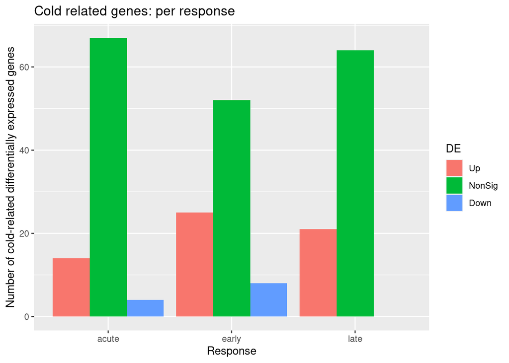

```r
dat$DE <- factor(dat$variable, levels = c("Up","NonSig","Down"))
ggplot(dat,aes(y=value,x=time,fill=DE)) +
    geom_col(position = "dodge") +
    xlab("Response") +
    ylab("Number of cold-related differentially expressed genes") +
    ggtitle("Cold related genes: per response")
```

```r
dat <- melt(countcoldtimepoint)
```

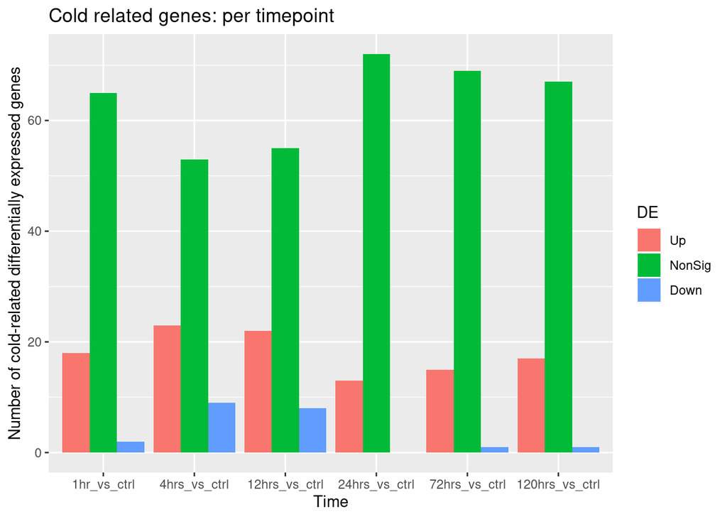

```r
dat$DE <- factor(dat$variable, levels = c("Up","NonSig","Down"))
dat$time <- factor(dat$time,levels = c("1hr_vs_ctrl","4hrs_vs_ctrl","12hrs_vs_ctrl","24hrs_vs_ctrl","72hrs_vs_ctrl","120hrs_vs_ctrl"))
ggplot(dat,aes(y=value,x=time,fill=DE)) +
    geom_col(position = "dodge") +
    xlab("Time") +
    ylab("Number of cold-related differentially expressed genes") +
    ggtitle("Cold related genes: per timepoint")
```

## 2.5 Figure 6 (and 7)

Plotting the Fatty acid biosynthesis pathway: ec00061 - we actually use the one for KEGG orthologs (ko)

```r
pspecies <- "ko"
pnumber <- "00061"
```

1. we get the pathway information

```r
pwy <- keggGet(paste0(pspecies,pnumber))
```

2. Get the enzymes

From the pathway

```r
ko <- pwy[[1]]$ORTHOLOGY
ko <- ko[grepl("EC",ko)]
tb <- tibble(KO=names(ko),EC=ko) %>%
  mutate(EC=sub("]","",sub(".*EC:","",EC))) %>%
  separate_longer_delim(EC," ")
```

From the annotation

```r
ez <- eCannot %>% mutate(EC=str_sub(EC,4)) %>%
  filter(EC %in% (tb %>% select(EC) %>% distinct() %>% unlist(use.names=FALSE)) & PID==paste0("ec",pnumber))
```

3. Collate the expression values

```r
ez %<>% left_join(scaledAvgExp,by="TxID")
```

4. Summarise

```r
ez %<>% left_join(tb,by="EC",relationship = "many-to-many") %>%
  group_by(KO) %>% summarise(across(where(is_double),median))
gdat <- ez %>% column_to_rownames("KO") %>% as.matrix()
```

5. plot

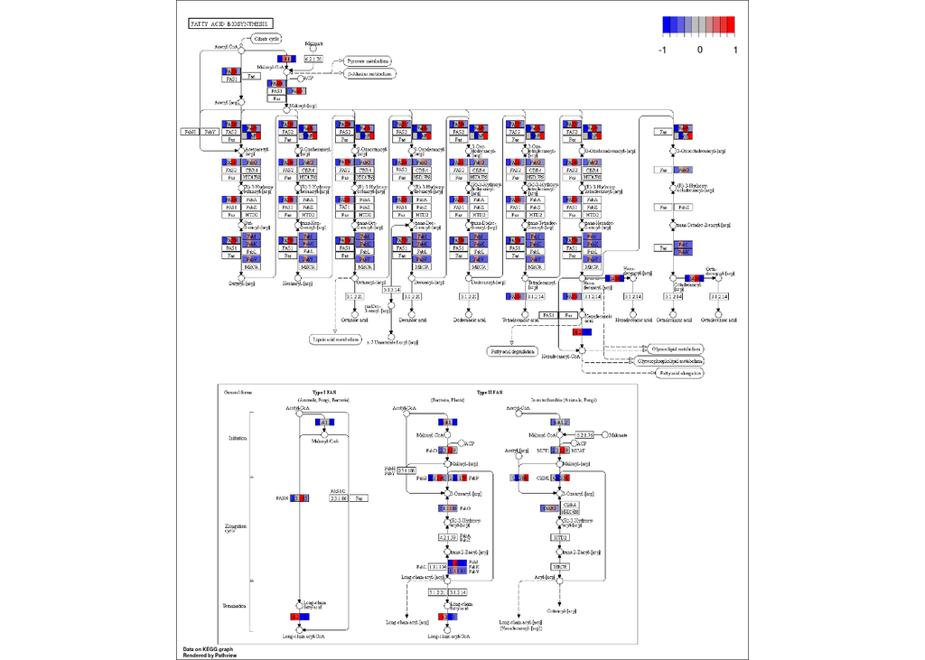

```r
# pathview(
#   gene.data=gdat,
#   species = pspecies,
#   pathway.id = pnumber,
#   out.suffix = "fatty-acid-biosynthesis",
#   kegg.dir=here("data/analysis/kegg"),
#   low=c("blue","blue"))

ggdraw() +
    draw_image(
        here("ko00061.fatty-acid-biosynthesis.multi.png"))
```

6. mv the result file in the result folder

```r
# outfile=list.files(here(),pattern=paste0(pspecies,pnumber,".*"))
# file.rename(outfile,here("data/analysis/kegg",outfile))
```

## 2.6 Figure 8

1. Getting GO related to cell wall

```r
toicellwall <- annot[grepl("cell wall",annot$Term),c("GOID","Term")]
toicellwall %<>% separate_longer_delim(everything(),delim="|") %>% distinct() %>% filter(grepl("cell wall",Term))

message(sprintf("There are %s GO terms related to cold in the assembly",nrow(toicellwall)))
```

```
## There are 8 GO terms related to cold in the assembly
```

```r
knitr::kable(toicellwall)
```

| GOID | Term |
| --- | --- |
| GO:0016998 | cell wall macromolecule catabolic process |
| GO:0071555 | cell wall organization |
| GO:0005618 | cell wall |
| GO:0009834 | plant-type secondary cell wall biogenesis |
| GO:1903338 | regulation of cell wall organization or biogenesis |
| GO:0042545 | cell wall modification |
| GO:0090379 | secondary cell wall biogenesis involved in seed trichome differentiation |
| GO:0052325 | cell wall pectin biosynthetic process |

```r
goicellwall <- unlist(as.vector(annot[Reduce("|",lapply(toicellwall$GOID,grepl,annot$GOID)),"TxID"]))
message(sprintf("There are %s candidates in the assembly",length(goicellwall)))
```

```
## There are 127 candidates in the assembly
```

```r
countcellwall <- as.data.frame(matrix(data = 0, nrow = length(degList), ncol = 2, dimnames = list(names(degList),c("Up","Down"))))
countcellwall$Up <- as.numeric(lapply(names(degList), function(x) sum((degList[[x]][["ID"]] %in% goicellwall)*(degList[[x]][["log2FoldChange"]] > 0))))
countcellwall$Down <- as.numeric(lapply(names(degList), function(x) sum((degList[[x]][["ID"]] %in% goicellwall)*(degList[[x]][["log2FoldChange"]] < 0))))
countcellwall$NonSig <- length(goicellwall) - countcellwall$Up - countcellwall$Down
countcellwall$time <- rownames(countcellwall)

countcellwalltimepoint <- as.data.frame(matrix(data = 0, nrow = length(degListPerTimePoint), ncol = 2, dimnames = list(names(degListPerTimePoint),c("Up","Down"))))
countcellwalltimepoint$Up <- as.numeric(lapply(names(degListPerTimePoint), function(x) sum((degListPerTimePoint[[x]][["ID"]] %in% goicellwall)*(degListPerTimePoint[[x]][["log2FoldChange"]] > 0))))
countcellwalltimepoint$Down <- as.numeric(lapply(names(degListPerTimePoint), function(x) sum((degListPerTimePoint[[x]][["ID"]] %in% goicellwall)*(degListPerTimePoint[[x]][["log2FoldChange"]] < 0))))
countcellwalltimepoint$NonSig <- length(goicellwall) - countcellwalltimepoint$Up - countcellwalltimepoint$Down
countcellwalltimepoint$time <- rownames(countcellwalltimepoint)

countcellwall$sample <- factor(rownames(countcellwall),levels = c("60min_vs_std","4hrs_vs_std","12hrsvs_std","24hrs_vs_std","72hrs_vs_std","120hrs_vs_std"))
```

4. Plotting the expression

```r
dat <- melt(countcellwall)
```

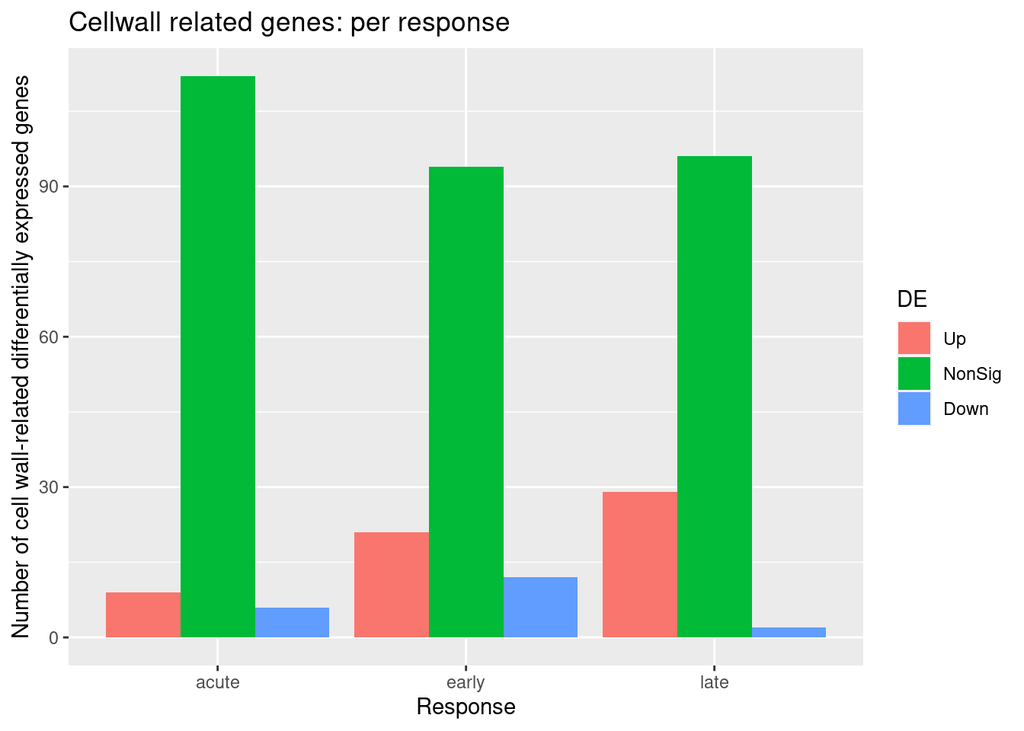

```r
dat$DE <- factor(dat$variable, levels = c("Up","NonSig","Down"))
ggplot(dat,aes(y=value,x=time,fill=DE)) +
    geom_col(position = "dodge") +
    xlab("Response") +
    ylab("Number of cell wall-related differentially expressed genes") +
    ggtitle("Cellwall related genes: per response")
```

```r
dat <- melt(countcellwalltimepoint)
```

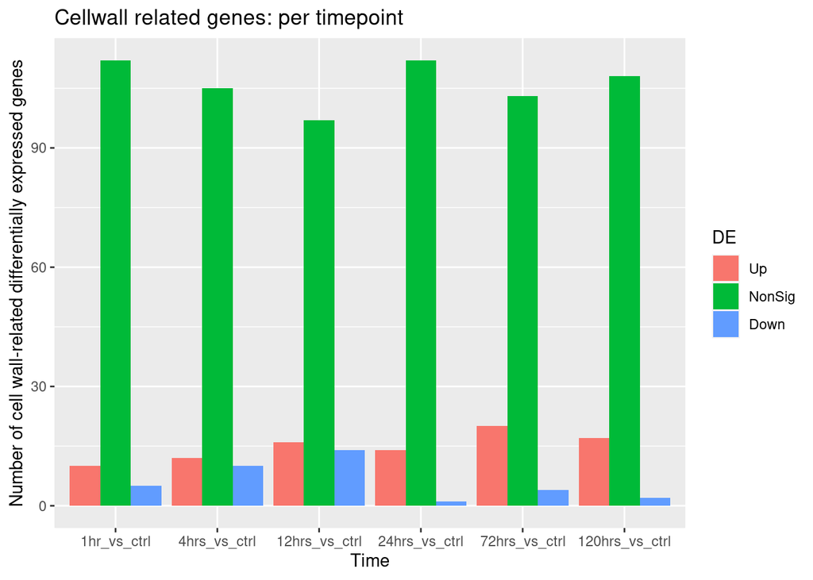

```r
dat$DE <- factor(dat$variable, levels = c("Up","NonSig","Down"))
dat$time <- factor(dat$time,levels = c("1hr_vs_ctrl","4hrs_vs_ctrl","12hrs_vs_ctrl","24hrs_vs_ctrl","72hrs_vs_ctrl","120hrs_vs_ctrl"))
ggplot(dat,aes(y=value,x=time,fill=DE)) +
    geom_col(position = "dodge") +
    xlab("Time") +
    ylab("Number of cell wall-related differentially expressed genes") +
    ggtitle("Cellwall related genes: per timepoint")
```

5. Reading cell wall thickness

```r
cellwallthickness <- reshape(read.table(here("doc/Cell-wall-measurement.tsv"),header = TRUE), idvar = "time_in_hours", timevar = "treatment", direction = "wide")
cellwallthickness$minus <- cellwallthickness$width_in_um.cold - cellwallthickness$width_in_um.control
cellwallthickness$divide <- cellwallthickness$width_in_um.cold / cellwallthickness$width_in_um.control
cellwallthickness$time_in_hours <- factor(cellwallthickness$time_in_hours, levels = c(1,4,12,24,48,72,120,240))
```

6. Plotting expression with cellwall thickness

```r
dat <- countcellwalltimepoint %>%
    select(Up, Down, time) %>%
    mutate(Down = (-1)*Down) %>%
    melt()
```

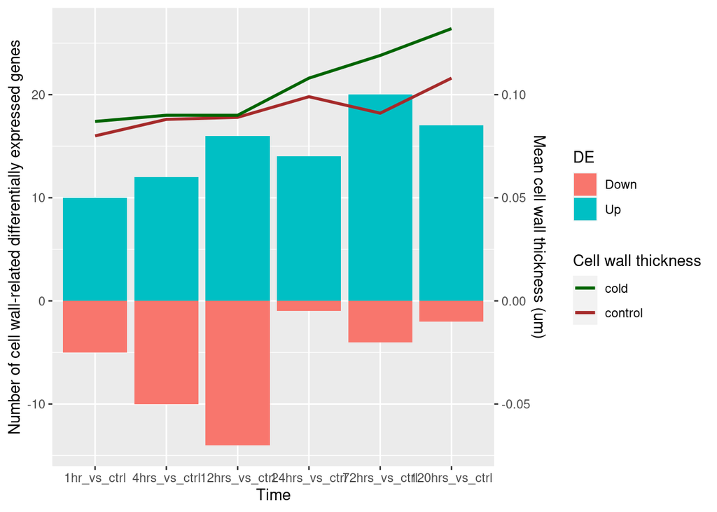

```r
dat$time <- factor(dat$time,levels = c("1hr_vs_ctrl","4hrs_vs_ctrl","12hrs_vs_ctrl","24hrs_vs_ctrl","72hrs_vs_ctrl","120hrs_vs_ctrl"))
dat$DE <- factor(dat$variable, levels = c("Down","Up"))

dat2 <- cellwallthickness[(cellwallthickness$time_in_hours != 240)&(cellwallthickness$time_in_hours != 48),1:3]
dat2$time <- factor(c("1hr_vs_ctrl","4hrs_vs_ctrl","12hrs_vs_ctrl","24hrs_vs_ctrl","72hrs_vs_ctrl","120hrs_vs_ctrl"),levels = c("1hr_vs_ctrl","4hrs_vs_ctrl","12hrs_vs_ctrl","24hrs_vs_ctrl","72hrs_vs_ctrl","120hrs_vs_ctrl"))

ggplot() + geom_col(data=dat,mapping = aes(y=value,x=time,fill=DE)) +
    geom_line(data=dat2,group=1,mapping=aes(x=time,y=width_in_um.control*200,colour="control"),size = 1) +
    geom_line(data=dat2,group=1,mapping=aes(x=time,y=width_in_um.cold*200,colour="cold"),size = 1) +
    xlab("Time") +
    scale_y_continuous(name = "Number of cell wall-related differentially expressed genes",
                                         sec.axis = sec_axis(trans = ~ . / 200,
                                                                                name = "Mean cell wall thickness (um)")) +
    scale_color_manual(name = "Cell wall thickness", values = c("control" = "brown", "cold" = "darkgreen"))
```